```r
#Installing Packages
    library(dplyr)
    library(data.table)
```

```r
    library(ggplot2)
    library(recommenderlab)
    library(reshape2)
    library(Matrix)
getwd()
```

```
## [1] "C:/Users/preet/Documents/GitHub/BeerRecommendationEngine"
```

# 1)Reading Dataset

```r
#Importing datasets
beer_data <- read.csv('./beer_data.csv',na.strings = "")
print(dim(beer_data))
```

```
## [1] 475984      3
```

### Checking for duplicates

```r
beer_data <- unique(beer_data)
print(dim(beer_data))
```

```
## [1] 475404      3
```

### Print summary

```r
summary(beer_data)
```

```
##   beer_beerid         review_profilename review_overall
##  Min.   :    3   northyorksammy:  1844   Min.   :0.000
##  1st Qu.: 1716   mikesgroove   :  1377   1st Qu.:3.500
##  Median :13896   BuckeyeNation :  1337   Median :4.000
##  Mean   :21663   Thorpe429     :  1072   Mean   :3.814
##  3rd Qu.:39397   ChainGangGuy  :  1046   3rd Qu.:4.500
##  Max.   :77317   (Other)       :468628   Max.   :5.000
##                  NA's          :   100
```

# 2) Exploration-

### How are ratings distributed?

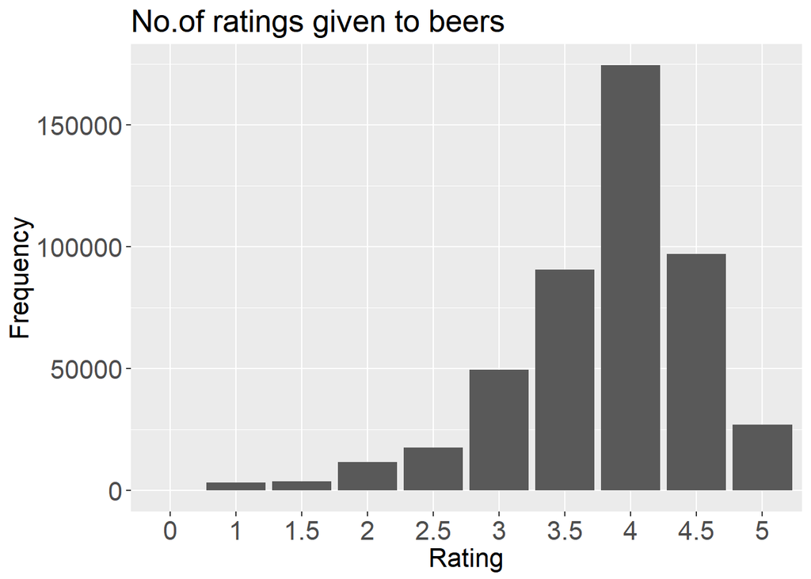

```r
ggplot(data = beer_data, aes(x = factor(review_overall))) +
  geom_bar() +
  labs(title="No.of ratings given to beers", x="Rating", y="Frequency") +
  theme(text = element_text(size=16),axis.text = element_text(size=16))
```

### Distribution of Average rating by user?

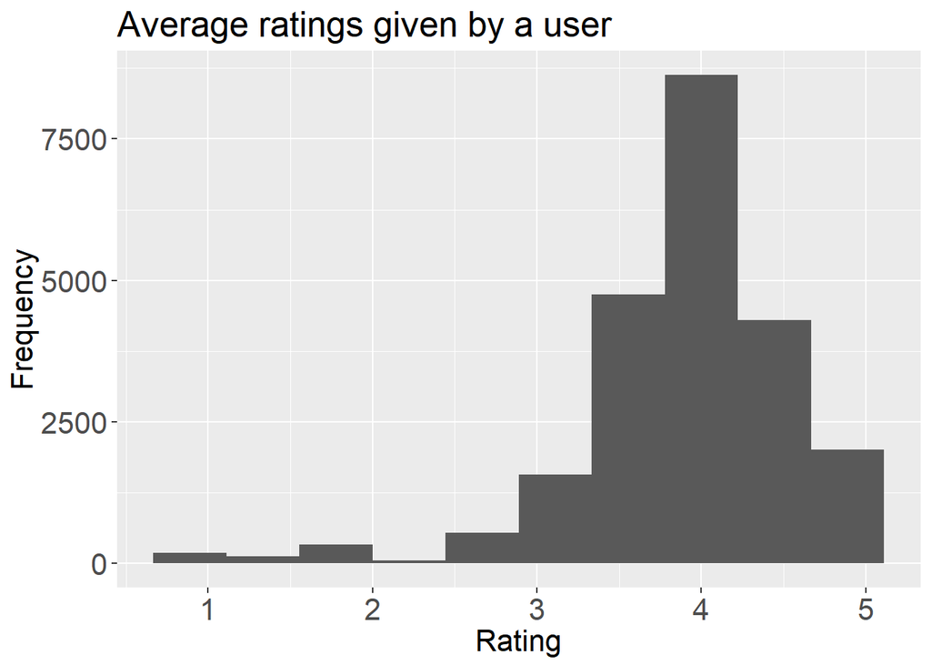

```r
x <- beer_data %>%
  group_by(review_profilename) %>%
  summarise(ratings_mean = mean(review_overall))
##How are rating distributed
ggplot(data = x, aes(x = ratings_mean)) +
  geom_histogram(bins = 10) +
  labs(title="Average ratings given by a user", x="Rating", y="Frequency") +
  theme(text = element_text(size=16),axis.text = element_text(size=16))
```

Most people rate beer highly.

### Distribution of nummber of rating given to a beer?

```r
beer_wise_count <- beer_data %>%
  group_by(beer_beerid) %>%
  summarise(rating_count = length(review_overall))

summary(beer_wise_count)
```

```
##   beer_beerid     rating_count
##  Min.   :    3   Min.   :  1.00
##  1st Qu.:16879   1st Qu.:  1.00
##  Median :37362   Median :  2.00
##  Mean   :36972   Mean   : 11.79
##  3rd Qu.:56232   3rd Qu.:  5.00
##  Max.   :77317   Max.   :980.00
```

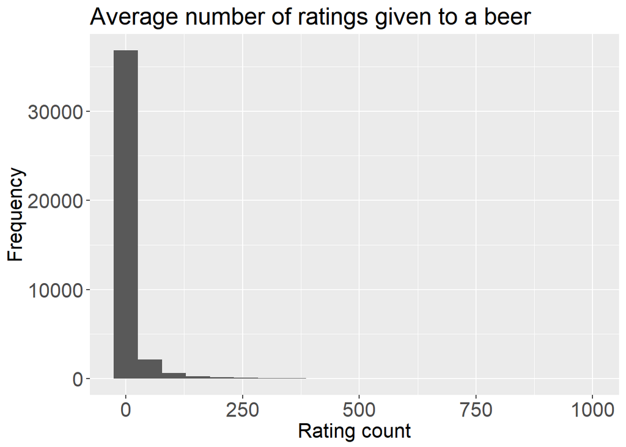

```r
ggplot(data= beer_wise_count,aes(x=rating_count)) +
  geom_histogram(bins = 20) +
  labs(title="Average number of ratings given to a beer", x="Rating count", y="Frequency") +
  theme(text = element_text(size=16),axis.text = element_text(size=16))
```

### Distribution of average number of rating given by a user?

```r
review_profilename_count <- beer_data %>%
  group_by(review_profilename) %>%
  summarise(rating_count = length(review_overall))

summary(review_profilename_count)
```

```
##    review_profilename  rating_count
##  0110x011   :    1    Min.   :   1.00
##  01Ryan10   :    1    1st Qu.:   1.00
##  03SVTCobra :    1    Median :   3.00
##  04101Brewer:    1    Mean   :  21.13
##  05Harley   :    1    3rd Qu.:  11.00
##  (Other)    :22492    Max.   :1844.00
##  NA's       :    1
```

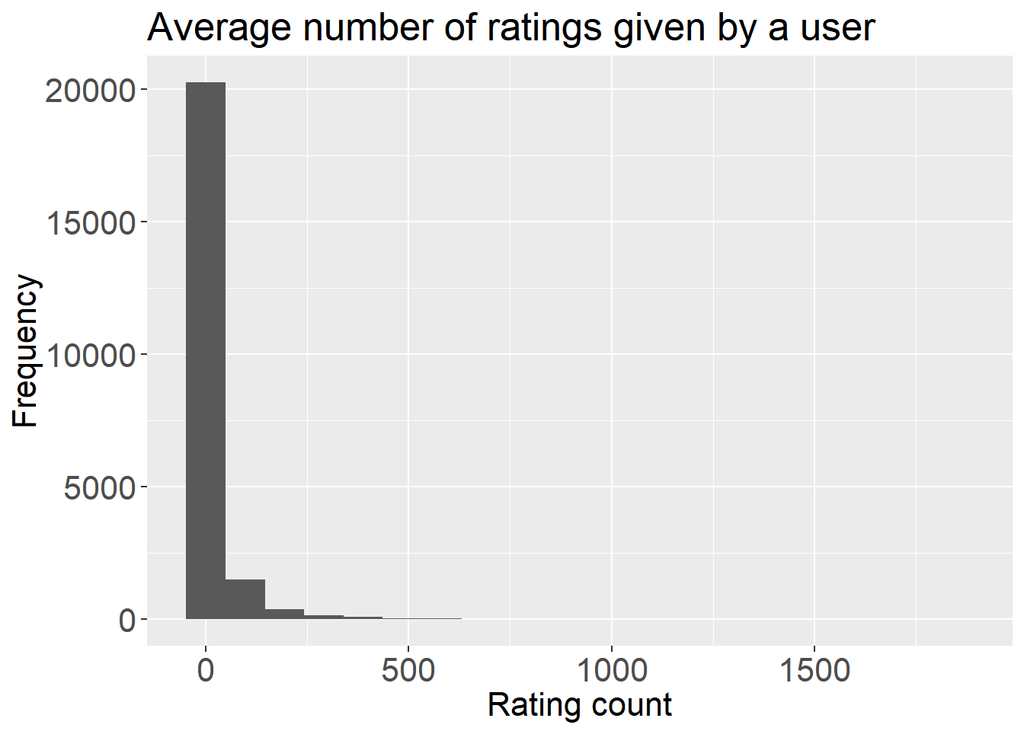

```r
ggplot(data= review_profilename_count,aes(x=rating_count)) + scale_fill_brewer(palette = "Spectral") +
  geom_histogram(bins = 20 ) +
  labs(title="Average number of ratings given by a user", x="Rating count", y="Frequency") +
  theme(text = element_text(size=16),axis.text = element_text(size=16))
```

### As we can see that only some beers have been rated many times while 75% of beer have less than 5 ratings. We will only use beers which atleast have more than 100 rating count. Let’s check how much beers we would be convering.

```r
sprintf('Coverage : %s%%',round(sum(beer_wise_count$rating_count >= 100)*100 / nrow(beer_wise_count),2))
```

```
## [1] "Coverage : 2.53%"
```

There are 2.53% of beers which have more than 100 ratings and we would be only interested in them. Recommender systems suffer with the problem of cold start and 100 is a good number to give appropriate recommendation. Let’s filter our data for only these beers.

```r
beer_of_interest <- beer_wise_count[beer_wise_count$rating_count >= 100,'beer_beerid']

beer_data_filter <- merge(beer_data, beer_of_interest, by = 'beer_beerid')

sprintf('Drop in observations : %s%%',(round(100 - (nrow(beer_data_filter)*100/nrow(beer_data)),2)))
```

```
## [1] "Drop in observations : 53.1%"
```

### As we can see by only taking 2.53% of beers recommendation we only loose 53.1% of rating data. Also filter users who have rated more than 10 ratings

```r
review_profilename_count <- beer_data_filter %>%
  group_by(review_profilename) %>%
  summarise(rating_count = length(review_overall))

user_of_interest <- review_profilename_count[review_profilename_count$rating_count > 10,'review_profilename']

beer_data_filter <- merge(beer_data_filter, user_of_interest, by = 'review_profilename')

sprintf('Drop in observations : %s%%',(round(100 - (nrow(beer_data_filter)*100/nrow(beer_data)),2)))
```

```
## [1] "Drop in observations : 60.8%"
```

### OVerall drop in data is 60.8%

```r
#Removing observations with no username
beer_data_filter <- beer_data_filter[!is.na(beer_data_filter$review_profilename),]

#This step will take a lot of time and memory
beer_data_filter1 <- acast(beer_data_filter, review_profilename ~ beer_beerid,value.var = 'review_overall',fun.aggregate=mean)

#Converting NaN to zero
beer_data_filter1[is.na(beer_data_filter1) ] = 0

## Making a sparse matrix
rating_matrix <- Matrix(beer_data_filter1,sparse = TRUE)
print(dim(rating_matrix))
```

```
## [1] 4336 1020
```

### That means 4336 users and 1020 beers. Now to convert the sparse matrix to a real rating matrix.

```r
real_matrix <- new("realRatingMatrix", data = rating_matrix)
```

### Let’s visualize similarity between users and items

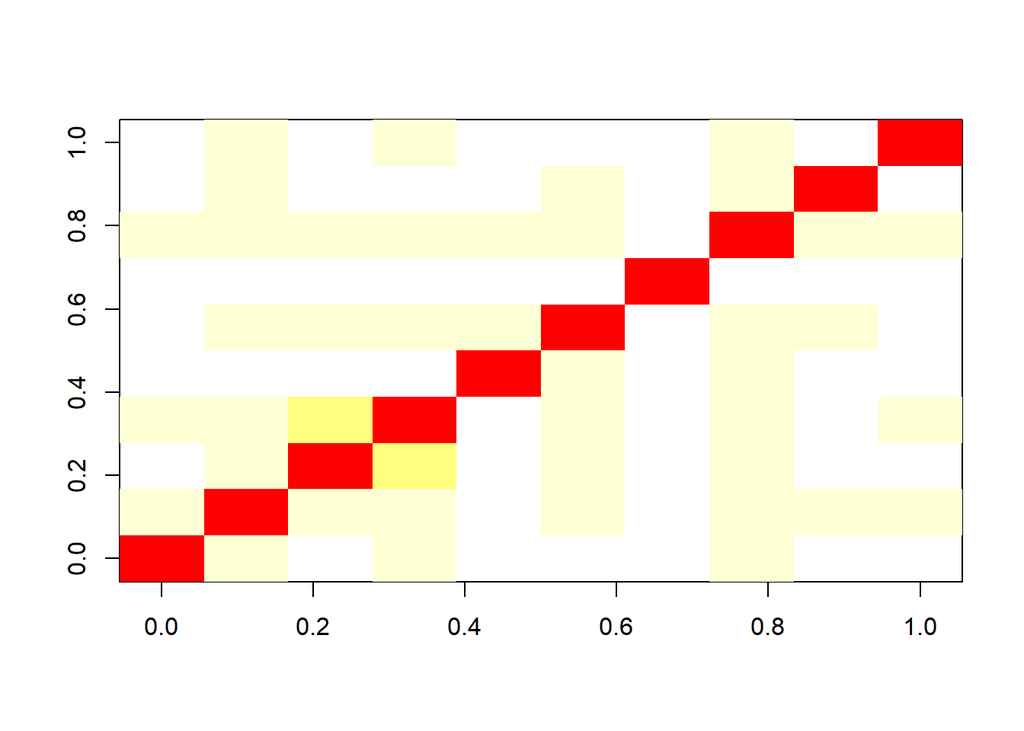

```r
#First 10 users
image(as.matrix(similarity(real_matrix[1:10,],method = 'cosine',which = 'users')))
```

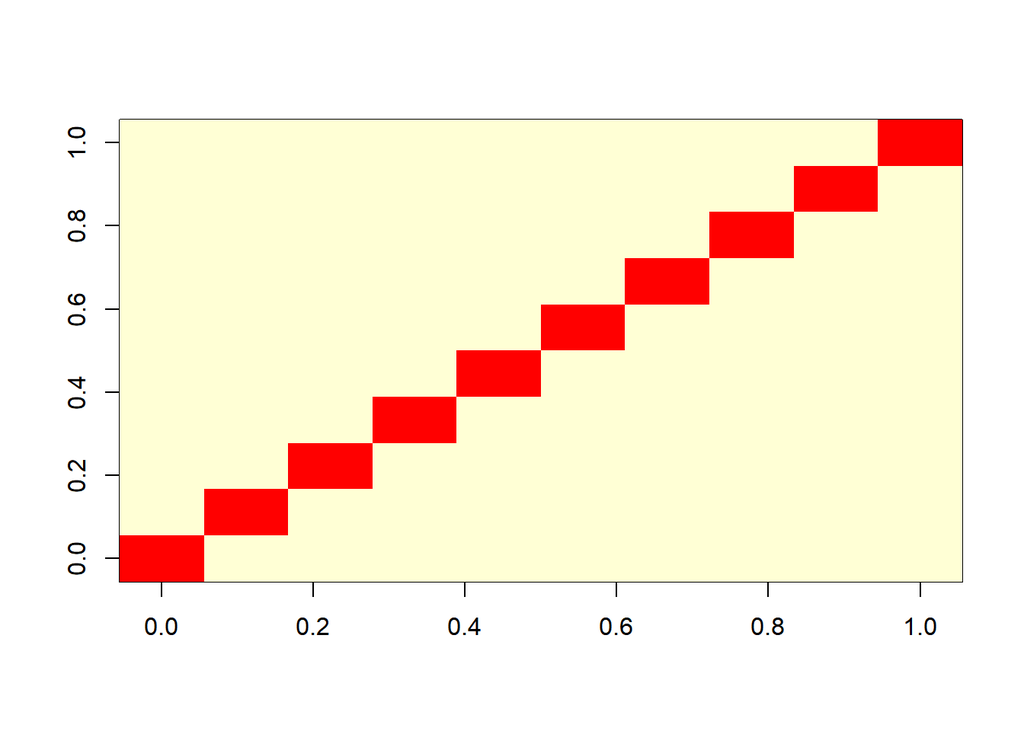

```r
#First 10 items
image(as.matrix(similarity(real_matrix[,1:10],method = 'cosine',which = 'items')))
```

## Split Validation

```r
# Making evaluation data set with 80 - 20 splot
eval_sets <- evaluationScheme(real_matrix, method = "split",train = 0.8, given = 10,goodRating = 3)

#Defining models to be evaluated
models <- list(
IBCF_cos = list(name = "IBCF",parameter = NULL),
UBCF_cos = list(name = "UBCF",parameter = NULL)
)

#evaluation
eval_results <- evaluate(x = eval_sets,method = models,n=seq(1,19,2))
```

```
## IBCF run fold/sample [model time/prediction time]
##   1  [11.93sec/0.26sec]
## UBCF run fold/sample [model time/prediction time]
##   1  [0.02sec/11.45sec]
```

```r
#Printing Model performance
print(eval_results$IBCF_cos@results[[1]])
```

```
## An object of class "confusionMatrix"
## Slot "cm":
##            TP         FP       FN       TN  precision       recall
## 1  0.02419355  0.9758065 30.56106 978.4389 0.02419355 0.0008725516
## 3  0.09907834  2.8974654 30.48618 976.5173 0.03302611 0.0038158580
## 5  0.16359447  4.8271889 30.42166 974.5876 0.03271889 0.0053890108
## 7  0.23156682  6.7523041 30.35369 972.6624 0.03308097 0.0082323255
## 9  0.28801843  8.6831797 30.29724 970.7316 0.03201805 0.0098227811
## 11 0.34331797 10.6117512 30.24194 968.8030 0.03125000 0.0112142603
## 13 0.39746544 12.5414747 30.18779 966.8733 0.03062965 0.0126638629
## 15 0.43894009 14.4781106 30.14631 964.9366 0.02934169 0.0139279369
## 17 0.48271889 16.4055300 30.10253 963.0092 0.02850136 0.0152876928
## 19 0.53917051 18.3110599 30.04608 961.1037 0.02850492 0.0169676310
##             TPR          FPR
## 1  0.0008725516 0.0009964645
## 3  0.0038158580 0.0029584552
## 5  0.0053890108 0.0049282155
## 7  0.0082323255 0.0068937072
## 9  0.0098227811 0.0088656662
## 11 0.0112142603 0.0108338251
## 13 0.0126638629 0.0128038984
## 15 0.0139279369 0.0147808794
## 17 0.0152876928 0.0167491199
## 19 0.0169676310 0.0186952565
##
## Slot "model":
## NULL
```

```r
print(eval_results$UBCF_cos@results[[1]])
```

```
## An object of class "confusionMatrix"
## Slot "cm":
##            TP         FP       FN       TN  precision      recall
## 1  0.08410138  0.9158986 30.50115 978.4988 0.08410138 0.003013212
## 3  0.26728111  2.7327189 30.31797 976.6820 0.08909370 0.013057742
## 5  0.42972350  4.5702765 30.15553 974.8445 0.08594470 0.019005934
## 7  0.56221198  6.4377880 30.02304 972.9770 0.08031600 0.024193956
## 9  0.68663594  8.3133641 29.89862 971.1014 0.07629288 0.031315213
## 11 0.81336406 10.1866359 29.77189 969.2281 0.07394219 0.036459690
## 13 0.92741935 12.0725806 29.65783 967.3422 0.07133995 0.041967754
## 15 1.06912442 13.9308756 29.51613 965.4839 0.07127496 0.047513198
## 17 1.18548387 15.8145161 29.39977 963.6002 0.06973435 0.051033798
## 19 1.30069124 17.6993088 29.28456 961.7154 0.06845743 0.054254891
##            TPR          FPR
## 1  0.003013212 0.0009339874
## 3  0.013057742 0.0027859847
## 5  0.019005934 0.0046597077
## 7  0.024193956 0.0065645924
## 9  0.031315213 0.0084796489
## 11 0.036459690 0.0103913597
## 13 0.041967754 0.0123142483
## 15 0.047513198 0.0142094042
## 17 0.051033798 0.0161304166
## 19 0.054254891 0.0180528935
##
## Slot "model":
## NULL
```

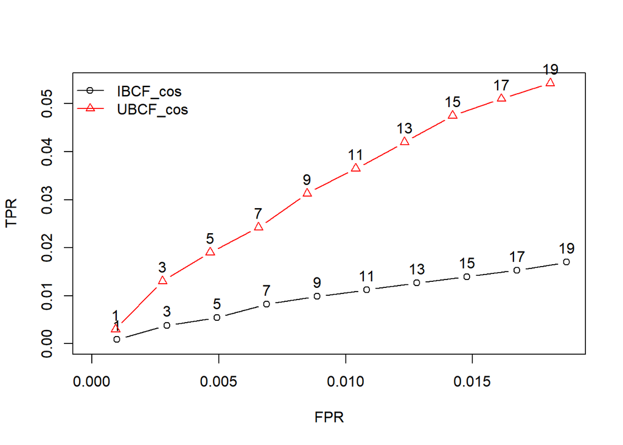

```r
#Making ROC curve
plot(eval_results, annotate = 1:2, legend="topleft")
```

As we can see UBCF model do better than IBCF models.

## Cross validation - 5 Fold

```r
#Making evaluation data set with 5 fold
eval_cv <- evaluationScheme(real_matrix, method="cross-validation",k=5,  given = 10, goodRating = 3)

#Evaluation
eval_results1 <- evaluate(x = eval_cv, method = models,n=seq(1,19,2))
```

```
## IBCF run fold/sample [model time/prediction time]
##   1  [11.36sec/0.2sec]
##   2  [11.41sec/0.21sec]
##   3  [11.34sec/0.21sec]
##   4  [11.69sec/0.22sec]
##   5  [11.55sec/0.2sec]
## UBCF run fold/sample [model time/prediction time]
##   1  [0.02sec/10.74sec]
##   2  [0.05sec/10.88sec]
##   3  [0.01sec/11.01sec]
##   4  [0sec/10.91sec]
##   5  [0.01sec/10.92sec]
```

```r
#Printing model performance
print(eval_results1$IBCF_cos@results[[1]])
```

```
## An object of class "confusionMatrix"
## Slot "cm":
##            TP         FP       FN       TN  precision      recall
## 1  0.03801843  0.9596774 30.35484 978.6475 0.03810624 0.001215181
## 3  0.11866359  2.8721198 30.27419 976.7350 0.03964588 0.004361402
## 5  0.20161290  4.7788018 30.19124 974.8283 0.04041570 0.008521786
## 7  0.26036866  6.7050691 30.13249 972.9021 0.03728143 0.010231160
## 9  0.31912442  8.6267281 30.07373 970.9804 0.03554016 0.011347013
## 11 0.37211982 10.5506912 30.02074 969.0565 0.03390720 0.012789036
## 13 0.43317972 12.4619816 29.95968 967.1452 0.03343077 0.014356546
## 15 0.48617512 14.3790323 29.90668 965.2281 0.03254252 0.015763375
## 17 0.55184332 16.2776498 29.84101 963.3295 0.03261044 0.017475660
## 19 0.60138249 18.1843318 29.79147 961.4228 0.03182036 0.018829661
##            TPR          FPR
## 1  0.001215181 0.0009795836
## 3  0.004361402 0.0029315028
## 5  0.008521786 0.0048765854
## 7  0.010231160 0.0068434048
## 9  0.011347013 0.0088044200
## 11 0.012789036 0.0107686577
## 13 0.014356546 0.0127196270
## 15 0.015763375 0.0146766733
## 17 0.017475660 0.0166147984
## 19 0.018829661 0.0185616661
##
## Slot "model":
## NULL
```

```r
print(eval_results1$UBCF_cos@results[[1]])
```

```
## An object of class "confusionMatrix"
## Slot "cm":
##           TP         FP       FN       TN  precision     recall        TPR
## 1  0.1025346  0.8974654 30.29032 978.7097 0.10253456 0.00457098 0.00457098
## 3  0.2834101  2.7165899 30.10945 976.8906 0.09447005 0.01222674 0.01222674
## 5  0.4205069  4.5794931 29.97235 975.0276 0.08410138 0.01887684 0.01887684
## 7  0.5668203  6.4331797 29.82604 973.1740 0.08097433 0.02448988 0.02448988
## 9  0.7142857  8.2857143 29.67857 971.3214 0.07936508 0.03105375 0.03105375
## 11 0.8582949 10.1417051 29.53456 969.4654 0.07802681 0.03727254 0.03727254
## 13 0.9792627 12.0207373 29.41359 967.5864 0.07532790 0.04056989 0.04056989
## 15 1.1059908 13.8940092 29.28687 965.7131 0.07373272 0.04661850 0.04661850
## 17 1.2384793 15.7615207 29.15438 963.8456 0.07285172 0.05130743 0.05130743
## 19 1.3594470 17.6405530 29.03341 961.9666 0.07154984 0.05615301 0.05615301
##             FPR
## 1  0.0009148314
## 3  0.0027689496
## 5  0.0046689904
## 7  0.0065592235
## 9  0.0084482626
## 11 0.0103409576
## 13 0.0122575093
## 15 0.0141683123
## 17 0.0160725171
## 19 0.0179893100
##
## Slot "model":
## NULL
```

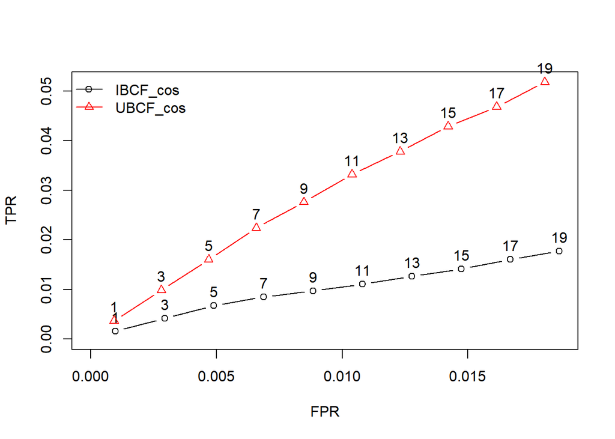

```r
#Making ROC curve
plot(eval_results1, annotate = 1:2, legend="topleft")
```

As we can see UBCF model do better than IBCF models even in cross validation approach.

```r
#Building UBCF model
Rec.model=Recommender(real_matrix,method="UBCF")

#Making Predictions
recom <- predict(Rec.model,1:dim(real_matrix)[1],data = real_matrix,n=5)

# For cokes
as(recom, "list")$cokes
```

```
## [1] "1093"  "6108"  "2751"  "50697" "2270"
```

```r
# For genog
as(recom, "list")$genog
```

```
## [1] "155"   "54904" "6076"  "57908" "43905"
```

```r
# For giblet
as(recom, "list")$giblet
```

```
## [1] "7971" "731"  "141"  "459"  "1545"
```